# Workshop: Intro til R 9.9. på FHS

Henrik Sørlie

9/9/2019

Hei, og takk til alle for at dere deltok på denne workshopen. Tross litt teknisk ball håper jeg dere satt igjen med i alle fall et lite innblikk i hvordan man kan jobbe med R. Som avtalt kommer her min utgave av det dokumentet vi jobbet med, ispedd litt annen informasjon jeg lovet å sende.

# Ressurser og hjelp

Her er lista over de viktigste ressursene jeg nevnte.

## Bøker

### R for Data Science

https://r4ds.had.co.nz

### YaRrr! The Pirate’s Guide to R

https://bookdown.org/ndphillips/YaRrr/

### Learning Statistics with R

https://learningstatisticswithr.com

## Anbefalte pakker

Under følger et utvalg nyttige pakker. Lenker til dokumentasjon ligger under hver pakke, men husk at for å ta i bruk en pakke trenger du bare å skrive f.eks. `install.packages("MBESS")` og deretter `library(MBESS)` i console.

### MBESS

Har flere nyttige funksjoner, bl.a. for å beregne reliabilitet og for å beregne konfidensintervaller på effektstørrelser.

https://www3.nd.edu/~kkelley/site/MBESS.html

### psych

Har vi allerede tittet litt på, med funksjonen pairs.panels(), men inneholder svært mange andre nyttige funksjoner også, bl.a. en hel haug med forskjellige reliabilitetsmål, og en rekke statistiske tester.

http://personality-project.org/r/psych/

### interactions

Ganske nytt tilskudd, kom nå i vår. Lettbrukt verktøykasse for interaksjoner. Anbefales!

https://interactions.jacob-long.com/index.html

### metafor

Heg har ikke brukt denne selv, men jeg har fått med meg at det er en av de mest brukte metaanalysepakkene til R.

http://www.metafor-project.org/doku.php

### lme4

En av flere multilevelpakker til R, men kanskje den nyeste og beste. Bruker, og bygger videre på, standard “regresjons/modellerings-syntax” for R.

https://github.com/lme4/lme4/

### lavaan

LAtent VAriable ANalysis. SEM-pakke for R

http://lavaan.ugent.be

### swirl

Lær deg R, i R. Denne er genial. Det blir litt som å spille et spill.

https://swirlstats.com

### likert

Verktøykasse og visualisering for likert-skalaer.

https://github.com/jbryer/likert

### papaja

Pakke for å R-pakke produsere APA-style artikler med RMarkdown. Denne er ikke tilgjengelig via CRAN ennå fordi den er under utvikling. Instruksjoner for nedlasting finnes imidlertid på linken under.

https://crsh.github.io/papaja_man/

## Diskusjonsforum

### Stack Overflow

Diskusjonsforum for programmering, statistikk, R, etc.

https://stackoverflow.com

### Cross Validated

Diskusjonsforum for statistikkspørsmål

https://stats.stackexchange.com

## Twitter

Bruk hashtaggen #rstats for spredning. Det kan være verdt å følge: @hadleywickham @rstudiotips @rstudio @lakens @dataandme @dsquintana @paulbuerkner @rlmcelreath @djnavarro @f2harrell @annemscheel @OrbenAmy @ProfAndyField @bmwiernik @simplystats @mcmc_stan @NeilLewisJr @FrederikAust @DTWillingham @jamesheathers @HarryDCrane @DrMowinckels @dantonnoriega @EJWagenmakers @richarddmorey @edgarmerkle @BrianNosek @OSFramework @SanneCSmid @page_gould @Space_Mog @psignificant @StatModeling @ikschneider @avehtari @jamovistats @JASPStats @siminevazire @JohnSakaluk @tcarpenter216 @Liza_Bolton @bcaffo @NSSDeviations @rdpeng @jtleek @AndrewFHayes @SachaEpskamp @BayesianSpecs @xieyihui @LisaDeBruine @timminglab @BodoWinter @StatStas @dmi3k @peder_isager @RLadiesOslo @MaartenvSmeden @rabaath @FrederikAust @thomasp85 @jonaslindeloev @jazzystats

Som sagt er dette en god miks av IOpsykologifolk, R-folk og statistikk/metodefolk.

# Arbeidsflyt fra workshopen

Her kommer det vi gjorde med datafilene jeg sendte ut på forhånd. Jeg har lagt inn litt ekstra kommentarer underveis, og litt flere argumenter i en del av funksjonene, for å vise ytterligere muligheter. Først laster vi inn de pakkene vi trenger:

```r
# Alt tekst etter en firkant (#) kjøres ikke som kode. Dette er nyttig for å kommentere koden inne i en chunk.

# I denne chunken aktiveres pakkene som trengs for å kjøre dette skriptet. Merk at for denne chunken er argumentene satt til message=FALSE og warning=FALSE, slik at disse meldingene ikke vises i outputen.

library(haven)
library(readr)
library(readxl)
library(dplyr)
library(psych)
library(ggplot2)
```

## Importere data

Så importerer vi data. I dette tilfellet henviser filbanen til en mappe “data” som ligger under working directory. Hvis du ønsker å kjøre dette skriptet selv så sørg for at filene ligger der, eller rediger filbanen i koden under slik at det blir riktig.

For mer detaljer om forskjellen på `read_csv()` og `read_csv2()`, sjekk hjelpfila ved å taste `?read_csv2()` i Console.

```r
seleksjonsdata <- read_spss("data/seleksjonsdata.sav") # Lese fra SPSS-fil
prestasjonsdataKS <- read_xlsx("data/Prestasjonsdata Krigsskolen.xlsx") # Lese fra Excel-fil
prestasjonsdataSKSK <- read_xlsx("data/Karakterer og SML SKSK.xlsx") # Mer fra Excel
prestasjonsdataLKS <- read_csv2("data/LuftKS karakterer.csv") # Og lese fra (europeisk) CSV-fil.
```

## Koble data

Neste skritt er å koble dataene. Først brukes `bind_rows()` til å bygge et datasett `prestasjonsdata` ved å hekte de respektive settene med prestasjonsdata på hverandre. Deretter brukes `left_join()` til å koble `prestasjonsdata` og `seleksjonsdata` til et datasett `data`. I funksjonen `left_join()` brukes argumentet `by =` til å angi hvilken kolonne som skal brukes som koblingsnøkkel. Dersom det ikke spesifiseres brukes automatisk kolonner som har likt navn i begge datasettene.

```r
# Først prestasjonsdata
prestasjonsdata <- bind_rows(prestasjonsdataKS, prestasjonsdataLKS)
prestasjonsdata <- bind_rows(prestasjonsdata, prestasjonsdataSKSK)

# Det er en preferansesak om man ønsker å "rydde etter seg" underveis ved å fjerne overflødige objekter. Det går an å "slå av og på" dette ved å fjerne eller legge til firkanttegnet foran linjen under:

# rm(prestasjonsdataKS, prestasjonsdataLKS, prestasjonsdataSKSK)

# Deretter Kobles prestasjonsdata og seleksjonsdata

data <- left_join(seleksjonsdata, prestasjonsdata, by = "ID")

# Vi brukte de to linjene under til å omdefinere de to variablene Gender og Skole til datatypen factor:

data$Gender <- as_factor(data$Gender)
data$Skole <- as_factor(data$Skole)

# rm(seleksjonsdata, prestasjonsdata)
```

## Utforske data

Vi var innom flere funksjoner for å få oversikt over dataene våre. Her var de viktigste. For mer info og alternativer, sjekk hjelpfilene til de individuelle funksjonene. Funksjonen `view()` føles veldig trygg og fin fordi den viser deg alle dataene, “SPSS/Excel-style”. Men den ødelegger workflowen litt fordi dataene åpnes i et eget vindu. Den egner seg derfor altså ikke i et script, men kan være grei å bruke i console ved behov. Utover det brukte vi:

```r
describe(data, IQR = TRUE)
```

```
##               vars   n   mean     sd median trimmed    mad   min    max
## ID               1 400 200.50 115.61 200.50  200.50 148.26  1.00 400.00
## Gender*          2 400   1.82   0.38   2.00    1.90   0.00  1.00   2.00
## AE               3 400   4.65   1.46   5.00    4.64   1.48  0.00   9.00
## Skolepoeng       4 400  48.82   3.07  48.65   48.78   3.09 40.84  56.92
## BS_karakter      5 400   6.86   1.20   6.92    6.87   1.22  2.90  11.27
## Tj_snitt         6 400   9.46   1.23   9.45    9.45   1.22  5.78  13.12
## Skole*           7 400   1.82   0.86   2.00    1.77   1.48  1.00   3.00
## Hovedkarakter    8 400  15.66   1.37  15.70   15.66   1.29 11.42  20.04
## MF_SML           9 400   8.29   1.14   8.00    8.25   1.48  5.00  12.00
##                range  skew kurtosis   se    IQR
## ID            399.00  0.00    -1.21 5.78 199.50
## Gender*         1.00 -1.66     0.76 0.02   0.00
## AE              9.00 -0.05     0.02 0.07   2.00
## Skolepoeng     16.08  0.08    -0.32 0.15   4.10
## BS_karakter     8.37 -0.02     0.14 0.06   1.63
## Tj_snitt        7.34  0.08    -0.03 0.06   1.65
## Skole*          2.00  0.36    -1.56 0.04   2.00
## Hovedkarakter   8.62  0.01    -0.09 0.07   1.74
## MF_SML          7.00  0.24     0.00 0.06   1.00
```

```r
head(data, n = 20)
```

```
## # A tibble: 20 x 9
##       ID Gender    AE Skolepoeng BS_karakter Tj_snitt Skole Hovedkarakter
##    <dbl> <fct>  <dbl>      <dbl>       <dbl>    <dbl> <fct>         <dbl>
##  1     1 Mann       5       52.9        6.79     7.81 Krig…          16.8
##  2     2 Mann       5       49.4        7.07     8.55 Krig…          17.4
##  3     3 Mann       5       46.4        6.03     7.63 Luft…          13.6
##  4     4 Mann       7       54.0        6.39    10.5  Krig…          17.1
##  5     5 Mann       5       49.8        6.15    10.1  Krig…          17.0
##  6     6 Kvinne     5       47.9        4.47     7.12 Krig…          15.4
##  7     7 Mann       6       47.4        6.50    10.5  Sjok…          14.0
##  8     8 Mann       6       52.9        7.78    10.9  Sjok…          16.5
##  9     9 Mann       4       48.1        6.71    10.7  Krig…          15.7
## 10    10 Mann       3       45.9        5.58     8.39 Krig…          16.9
## 11    11 Mann       4       48.6        6.21    10.4  Sjok…          15.7
## 12    12 Mann       5       53.9        6.16     9.67 Krig…          17.2
## 13    13 Kvinne     7       55.5        6.98     9.28 Krig…          17.7
## 14    14 Mann       3       47.9        4.19     9.31 Sjok…          14.2
## 15    15 Mann       2       48.1        5.45     9.09 Sjok…          14.0
## 16    16 Mann       4       53.1       10.0     10.9  Krig…          16.4
## 17    17 Mann       2       46.3        4.98     8.23 Sjok…          13.4
## 18    18 Mann       5       44.7        7.79     8.89 Luft…          15.0
## 19    19 Mann       5       50.3        7.60     8.90 Sjok…          15.2
## 20    20 Mann       4       47.4        5.32     9.58 Krig…          14.0
## # … with 1 more variable: MF_SML <dbl>
```

Dette kan selvsagt kombineres med subsetting og sortering, slik at jeg f.eks. kan be om å få se de 20 radene med høyest Skolepoeng:

```r
head(arrange(data, desc(Skolepoeng)), n = 20)
```

```
## # A tibble: 20 x 9
##       ID Gender    AE Skolepoeng BS_karakter Tj_snitt Skole Hovedkarakter
##    <dbl> <fct>  <dbl>      <dbl>       <dbl>    <dbl> <fct>         <dbl>
##  1    96 Kvinne     7       56.9        7.82     9.89 Krig…          18.2
##  2   277 Kvinne     8       56.6        6.38    13.0  Sjok…          16.3
##  3   182 Mann       6       55.7        8.77    10.3  Krig…          17.7
##  4    13 Kvinne     7       55.5        6.98     9.28 Krig…          17.7
##  5   123 Mann       5       55.4        6.71     9.11 Krig…          17.2
##  6   207 Kvinne     6       55.4        8.72     8.46 Krig…          20.0
##  7   350 Mann       6       55.3        6.82     9.07 Krig…          18.2
##  8    99 Mann       6       55.3        6.65     9.10 Sjok…          16.5
##  9   322 Mann       7       55.3        8.14    11.1  Krig…          17.9
## 10   384 Mann       6       55.1        6.69    10.7  Krig…          16.9
## 11   100 Mann       7       55.0        7.16    10.3  Krig…          17.9
## 12   132 Kvinne     8       55.0        8.48    10.9  Sjok…          15.9
## 13    84 Kvinne     7       55.0        8.42     8.89 Krig…          17.7
## 14   194 Kvinne     5       54.9        6.04     9.94 Krig…          17.2
## 15    97 Mann       6       54.6        6.09     8.61 Krig…          19.0
## 16   251 Kvinne     8       54.5        6.97    10.9  Sjok…          15.7
## 17   370 Mann       7       54.4        6.29     8.09 Krig…          17.5
## 18    44 Mann       6       54.3        7.99    10.6  Krig…          19.0
## 19   169 Kvinne     8       54.3        6.86     9.83 Krig…          17.2
## 20   167 Mann       5       54.3        7.72    11.5  Krig…          16.5
## # … with 1 more variable: MF_SML <dbl>
```

```r
tail(data, n = 20)
```

```
## # A tibble: 20 x 9
##       ID Gender    AE Skolepoeng BS_karakter Tj_snitt Skole Hovedkarakter
##    <dbl> <fct>  <dbl>      <dbl>       <dbl>    <dbl> <fct>         <dbl>
##  1   381 Mann       5       52.9        6.06    10.7  Krig…          17.4
##  2   382 Mann       4       51.2        5.29     9.17 Krig…          15.7
##  3   383 Mann       2       49.6        4.40     8.68 Krig…          13.9
##  4   384 Mann       6       55.1        6.69    10.7  Krig…          16.9
##  5   385 Mann       6       50.0        6.69    10.7  Sjok…          15.1
##  6   386 Mann       5       50.3        6.11     9.44 Krig…          16.4
##  7   387 Mann       5       45.1        4.07     8.71 Sjok…          14.4
##  8   388 Mann       3       46.2        6.91     7.60 Sjok…          13.2
##  9   389 Mann       5       44.4        6.62     9.01 Luft…          15.2
## 10   390 Mann       5       50.9        6.01    11.2  Krig…          16.6
## 11   391 Mann       3       45.9        6.13     8.24 Sjok…          14.1
## 12   392 Mann       6       53.7        7.20     9.98 Krig…          17.5
## 13   393 Mann       5       48.5        8.42    10.2  Sjok…          16.3
## 14   394 Mann       5       43.3        8.58    10.8  Sjok…          15.1
## 15   395 Mann       3       47.4        5.52     8.77 Sjok…          15.8
## 16   396 Mann       6       50.9        5.98     7.75 Sjok…          15.5
## 17   397 Mann       7       52.5        8.77     9.96 Krig…          18.5
## 18   398 Mann       8       50.0        7.22    11.5  Sjok…          17.4
## 19   399 Mann       5       45.5        7.04     9.29 Sjok…          14.0
## 20   400 Mann       4       53.9        7.21     9.70 Krig…          15.8
## # … with 1 more variable: MF_SML <dbl>
```

```r
summary(data)
```

```
##        ID           Gender          AE          Skolepoeng
##  Min.   :  1.0   Kvinne: 72   Min.   :0.000   Min.   :40.84
##  1st Qu.:100.8   Mann  :328   1st Qu.:4.000   1st Qu.:46.74
##  Median :200.5                Median :5.000   Median :48.65
##  Mean   :200.5                Mean   :4.647   Mean   :48.82
##  3rd Qu.:300.2                3rd Qu.:6.000   3rd Qu.:50.84
##  Max.   :400.0                Max.   :9.000   Max.   :56.92
##   BS_karakter        Tj_snitt                  Skole     Hovedkarakter
##  Min.   : 2.904   Min.   : 5.776   Krigsskolen    :191   Min.   :11.42
##  1st Qu.: 6.037   1st Qu.: 8.631   Luftkrigsskolen: 91   1st Qu.:14.78
##  Median : 6.915   Median : 9.452   Sjokrigsskolen :118   Median :15.70
##  Mean   : 6.860   Mean   : 9.462                         Mean   :15.66
##  3rd Qu.: 7.672   3rd Qu.:10.280                         3rd Qu.:16.52
##  Max.   :11.270   Max.   :13.118                         Max.   :20.04
##      MF_SML
##  Min.   : 5.00
##  1st Qu.: 8.00
##  Median : 8.00
##  Mean   : 8.29
##  3rd Qu.: 9.00
##  Max.   :12.00
```

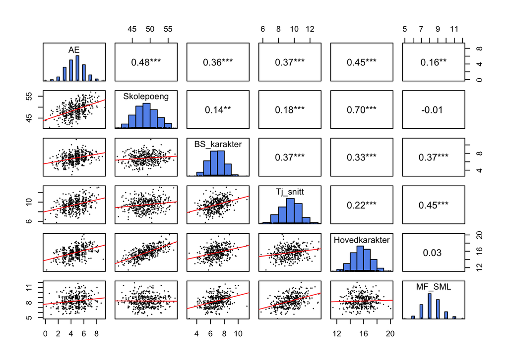

```r
pairs.panels(data[,-c(1, 2, 7)], density = FALSE, lm = TRUE, ellipses = FALSE, jiggle = TRUE, hist.col = "cornflowerblue", stars = TRUE, cex.cor = .6, cex = .2)
```

`pairs.panels()` har mange valgmuligheter. Her er det bare å utforske argumentene i hjelpfila.

## Plotte data

Vi brukte pakken `ggplot2` til å plotte data. Med funksjonen `ggplot()` bygger du plot steg for steg ved å først angi hvilket datasett du vil bruke, deretter “mappe” variabler til egenskaper/dimensjoner i plottet med `aes()`-funksjonen, som f.eks. x-akse, y-akse, farge etc. Til slutt velger du en eller flere geoms som du legger lagvis for å velge det visuelle uttrykket. Her finnes det uendelige muligheter. Det er bare å google for inspirasjon. Under er eksemplene vi brukte i workshopen:

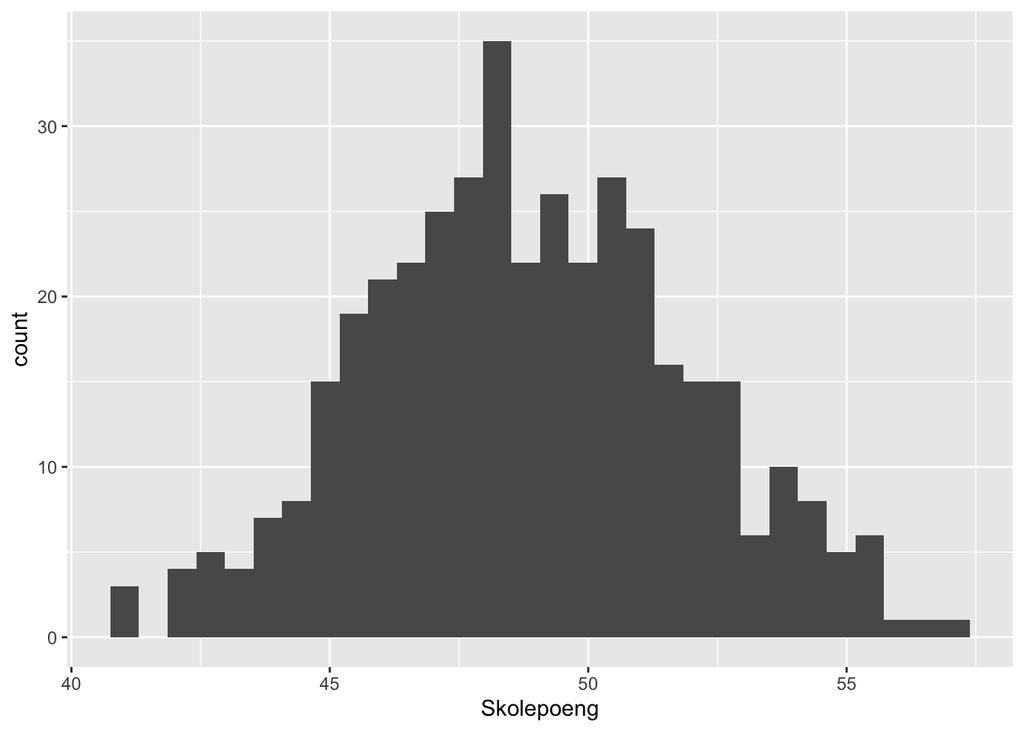

```r
plot1 <- ggplot(data, aes(x = Skolepoeng)) +
        geom_histogram()
plot1
```

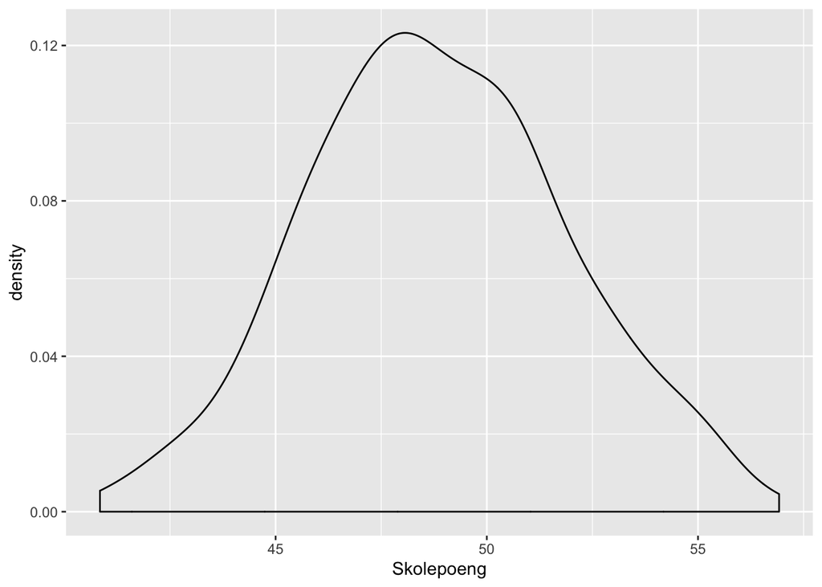

```r
plot2 <- ggplot(data, aes(x = Skolepoeng)) +
        geom_density()
plot2
```

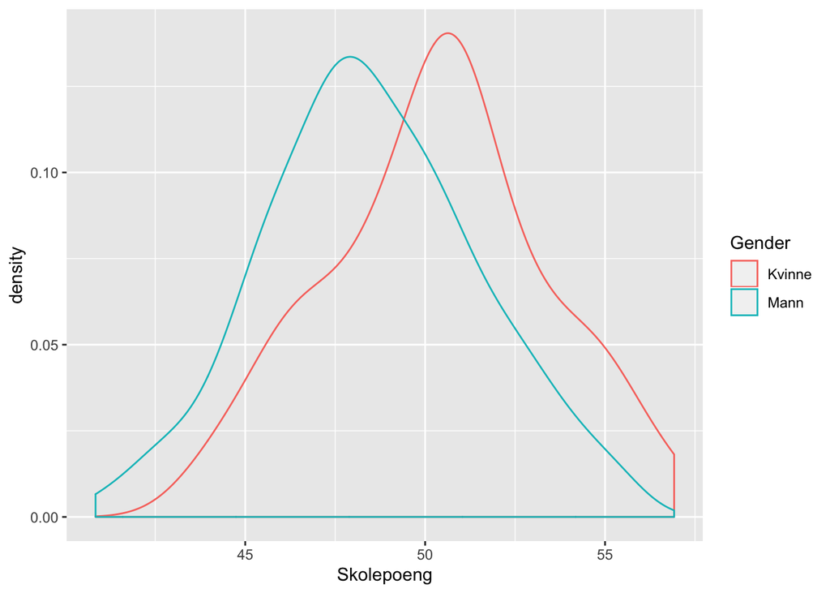

```r
plot3 <- ggplot(data, aes(x = Skolepoeng, colour = Gender)) +
        geom_density()
plot3
```

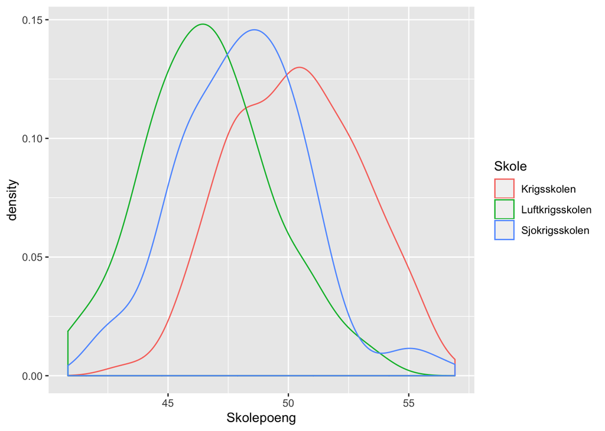

```r
plot4 <- ggplot(data, aes(x = Skolepoeng, colour = Skole)) +
        geom_density()
plot4
```

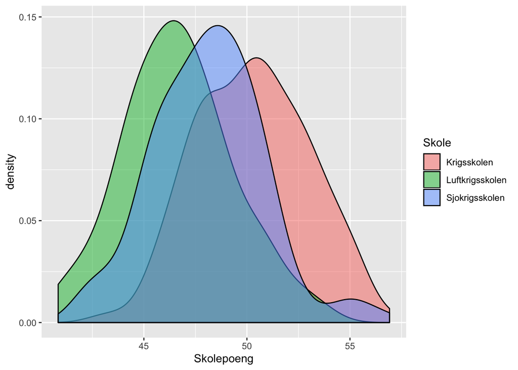

```r
plot4 <- ggplot(data, aes(x = Skolepoeng, fill = Skole)) +
        geom_density(alpha = .5)
plot4
```

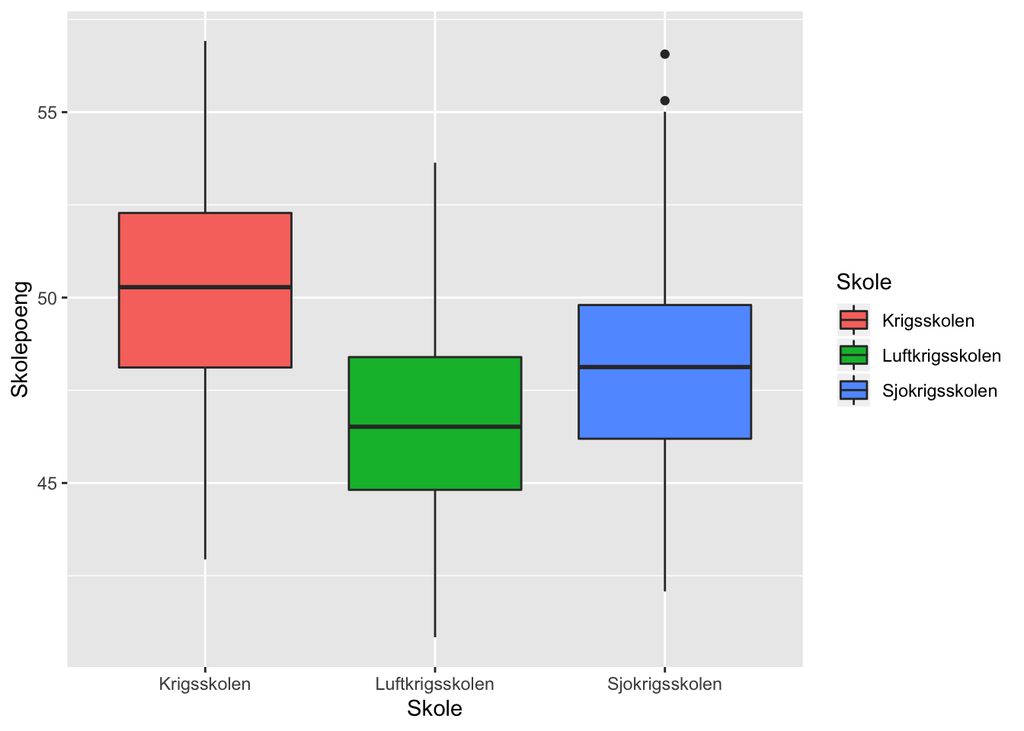

```r
plot5 <- ggplot(data, aes(x = Skole, y = Skolepoeng, fill = Skole)) +
        geom_boxplot()
plot5
```

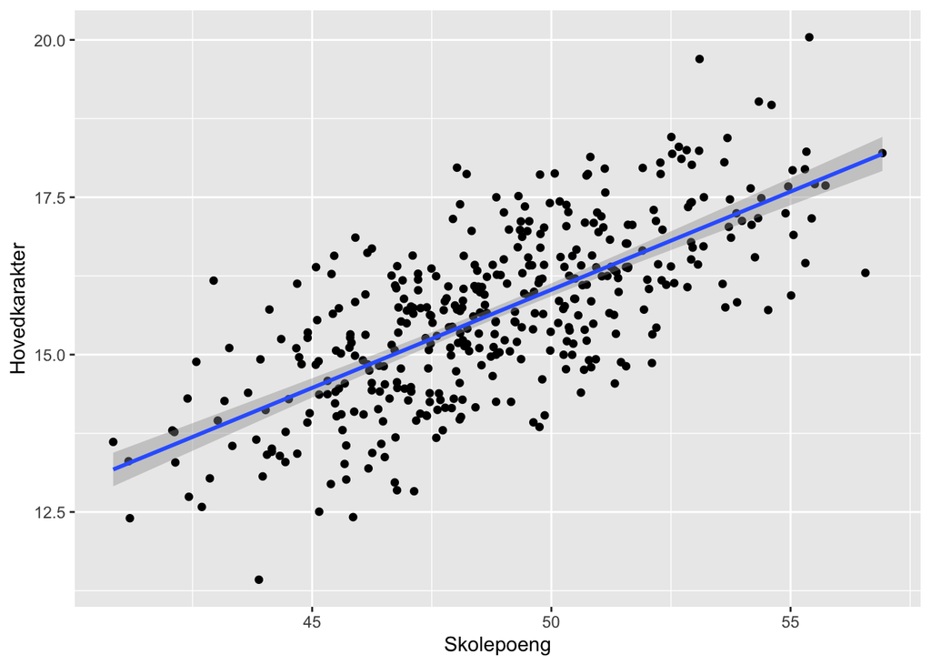

```r
plot6 <- ggplot(data, aes(x = Skolepoeng, y = Hovedkarakter)) +
        geom_point() +
        geom_smooth(method = "lm")
plot6
```

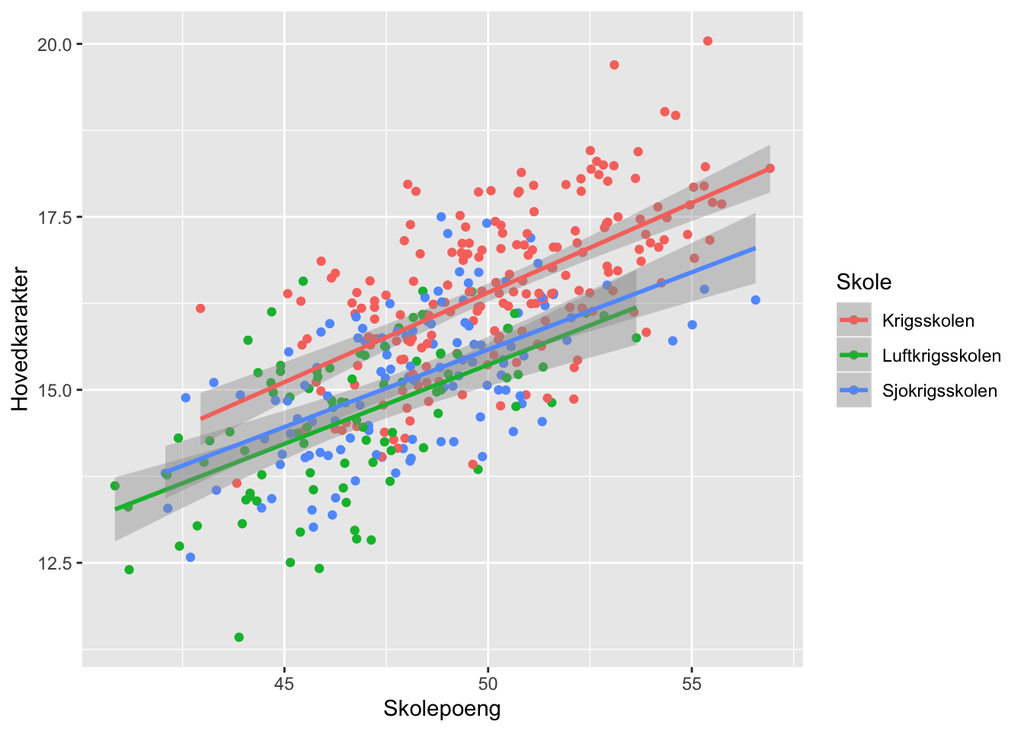

```r
plot7 <- ggplot(data, aes(x = Skolepoeng, y = Hovedkarakter, colour = Skole)) +
        geom_point() +
        geom_smooth(method = "lm")
plot7
```

For valgmuligheter og argumenter, sjekk hjelpfila til de individuelle geom-funksjonene eller aes-funksjonen. Beste tips er imidlertid boka R for data science (link lengre opp i dokumentet) som inneholder et veldig bra kapittel om ggplot.

## Regresjoner

```r
model1 <- lm(Hovedkarakter ~ Skolepoeng + AE, data = data)
```

Nå ligger denne modellen lagret som et objekt. Info om modellen kan hentes ut med f.eks. funksjonen `summary()`.

```r
summary(model1)
```

```
##
## Call:
## lm(formula = Hovedkarakter ~ Skolepoeng + AE, data = data)
##
## Residuals:
##      Min       1Q   Median       3Q      Max
## -2.49661 -0.61941 -0.01944  0.62881  2.65085
##
## Coefficients:
##             Estimate Std. Error t value Pr(>|t|)
## (Intercept)  1.30893    0.80603   1.624 0.105185
## Skolepoeng   0.28141    0.01792  15.704  < 2e-16 ***
## AE           0.13237    0.03781   3.501 0.000516 ***
## ---
## Signif. codes:  0 '***' 0.001 '**' 0.01 '*' 0.05 '.' 0.1 ' ' 1
##
## Residual standard error: 0.9629 on 397 degrees of freedom
## Multiple R-squared:  0.5067, Adjusted R-squared:  0.5042
## F-statistic: 203.9 on 2 and 397 DF,  p-value: < 2.2e-16
```

Deretter kan vi f.eks. spesifisere en ny modell som er lik som den forrige, men med en ekstra uavhengig variabel:

```r
model2 <- lm(Hovedkarakter ~ Skolepoeng + AE + Tj_snitt, data = data)
summary(model2)
```

```
##
## Call:
## lm(formula = Hovedkarakter ~ Skolepoeng + AE + Tj_snitt, data = data)
##
## Residuals:
##      Min       1Q   Median       3Q      Max
## -2.30226 -0.65510 -0.00289  0.62546  2.73972
##
## Coefficients:
##             Estimate Std. Error t value Pr(>|t|)
## (Intercept)  0.73882    0.87263   0.847  0.39770
## Skolepoeng   0.28145    0.01788  15.742  < 2e-16 ***
## AE           0.11036    0.03992   2.764  0.00597 **
## Tj_snitt     0.07090    0.04213   1.683  0.09322 .
## ---
## Signif. codes:  0 '***' 0.001 '**' 0.01 '*' 0.05 '.' 0.1 ' ' 1
##
## Residual standard error: 0.9607 on 396 degrees of freedom
## Multiple R-squared:  0.5102, Adjusted R-squared:  0.5064
## F-statistic: 137.5 on 3 and 396 DF,  p-value: < 2.2e-16
```

…og en tredje modell, med enda en:

```r
model3 <- lm(Hovedkarakter ~ Skolepoeng + AE + Tj_snitt + BS_karakter, data = data)
summary(model3)
```

```
##
## Call:
## lm(formula = Hovedkarakter ~ Skolepoeng + AE + Tj_snitt + BS_karakter,
##     data = data)
##
## Residuals:
##      Min       1Q   Median       3Q      Max
## -2.45489 -0.64147  0.04957  0.60720  2.67185
##
## Coefficients:
##              Estimate Std. Error t value Pr(>|t|)
## (Intercept) -0.251303   0.858146  -0.293    0.770
## Skolepoeng   0.285567   0.017230  16.574  < 2e-16 ***
## AE           0.054062   0.039700   1.362    0.174
## Tj_snitt     0.004427   0.042225   0.105    0.917
## BS_karakter  0.244817   0.043169   5.671 2.74e-08 ***
## ---
## Signif. codes:  0 '***' 0.001 '**' 0.01 '*' 0.05 '.' 0.1 ' ' 1
##
## Residual standard error: 0.925 on 395 degrees of freedom
## Multiple R-squared:  0.547,  Adjusted R-squared:  0.5425
## F-statistic: 119.3 on 4 and 395 DF,  p-value: < 2.2e-16
```

Modellene kan sammenlignes med funksjonen `anova()`:

```r
anova(model1, model2, model3)
```

```
## Analysis of Variance Table
##
## Model 1: Hovedkarakter ~ Skolepoeng + AE
## Model 2: Hovedkarakter ~ Skolepoeng + AE + Tj_snitt
## Model 3: Hovedkarakter ~ Skolepoeng + AE + Tj_snitt + BS_karakter
##   Res.Df    RSS Df Sum of Sq       F    Pr(>F)
## 1    397 368.08
## 2    396 365.46  1    2.6132  3.0544    0.0813 .
## 3    395 337.95  1   27.5161 32.1614 2.744e-08 ***
## ---
## Signif. codes:  0 '***' 0.001 '**' 0.01 '*' 0.05 '.' 0.1 ' ' 1
```

Det finnes andre muligheter til å sammenligne modellene også. Jeg anbefaler å google i vei, for dette finnes det mange tutorials på. Evt. sjekk en av de gratis online bøkene jeg inkluderte link til. Slutningsstatistikk ramler litt utenfor scope på “R for Data science” tror jeg, men både “Learning Statistics with R” og “A Pirate’s Guide to…” er nok bra på dette.